# Challenge 3: Graphical abstract

Solene Derville - solene.derville@oregonstate.edu

Feb 28, 2023

## Challenge objective: Create a graphical abstract from Louzier et a. 2009 “Predicting the distribution of Sasquatch in western North America: anything goes with ecological niche modelling”

1. Open an appropriate canva template on www.canva.com (e.g. Facebook post, presentation, infographics etc. have suitable formats, but you can choose any template)
2. Create a graphical abstract including: context, question, method, main results, reference to article and contact info.
3. Find illustrations either in the “Elements” tab in Canva, or uploading your own (e.g., map of North America in the dropbox).

## Example

Making a good graphical abstract is rather subjective. I tried to produce one (below) by following a couple rules:

1. I limited the number of words but made sure that I presented the context, objective of the study, results and conclusion/main take away message,
2. I included the reference to the article (if this was my paper, I would also add a logo and contact info),
3. I limited the color palette to analogous colors (sitting next to each other on the color wheel) in adequation with the theme (brown colors reminding of the woods, bears etc..),
4. I used only two different fonts (which I then derived in different colors and size),
5. I payed as much attention as I could to alignments between all of the elements in the design,
6. I tried to leave as much free space as possible around the text blocks and images,
7. I used the short title of the paper (the one that is usually shown in the top margin of the printed paper pdf) instead of the full title because I thought it was bit more “punchy” and easier to understand.

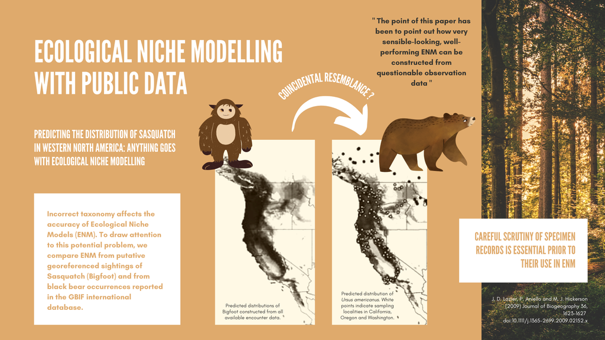